# AbercrombieJaxon_Assignment3_PM566

Jaxon Abercrombie

10/28/2021

### APIs

To find papers under the search term of “sars-cov-2 trial vaccine,” the following code was produced, and the number of results were counted:

```r
website <- xml2::read_html("https://pubmed.ncbi.nlm.nih.gov/?term=sars-cov-2+trial+vaccine")

counts <- xml2::xml_find_first(website, "/html/body/main/div[9]/div[2]/div[2]/div[1]/div[1]/span")

counts <- as.character(counts)
```

Based on the search term(s) “sars-cov-2 trial vaccine,” there were 2,336 papers found.

To download paper details for the first 250 papers and format the IDs sourced from the code:

```r
query_ids <- GET(
      url   = "https://eutils.ncbi.nlm.nih.gov/",
      path = "entrez/eutils/esearch.fcgi",
      query = list(db       = "pubmed",
                   term     = "sars-cov-2 trial vaccine",
                   rettype = "abstract",
                   retmax   = 250)
    )

ids <- httr::content(query_ids)
ids <- as.character(ids)
ids <- stringr::str_extract_all(ids, "<Id>[0-9]+</Id>")[[1]]
ids <- stringr::str_remove_all(ids, "<Id>|</Id>")
```

To then create a dataset for the first 250 papers and their information about ID, title, journal name, publication date, and abstract:

```r
publications <- GET(
  url = "https://eutils.ncbi.nlm.nih.gov/",
  path = "entrez/eutils/efetch.fcgi",
  query = list(
    db = "pubmed",
    id = paste(ids, collapse = ","),
    retmax = 250,
    rettype = "abstract"
    ))
publications <- httr::content(publications)
publications_txt <- as.character(publications)

pub_char_list <- xml2::xml_children(publications)
pub_char_list <- sapply(pub_char_list, as.character)

# From Lab 7, and the other variables are modeled after the next three lines of code
abstracts <- str_extract(pub_char_list, "<Abstract>[[:print:][:space:]]+</Abstract>")
abstracts <- str_remove_all(abstracts, "</?[[:alnum:]- =\"]+>")
abstracts <- str_replace_all(abstracts, "[[:space:]]+", " ")

# For article titles...
titles <- str_extract(pub_char_list, "<ArticleTitle>[[:print:][:space:]]+</ArticleTitle>")
titles <- str_remove_all(titles, "</?[[:alnum:]- =\"]+>")

# For journal titles...
journals <- str_extract(pub_char_list, "<Title>[[:print:][:space:]]+</Title>")
journals <- str_remove_all(journals, "</?[[:alnum:]- =\"]+>")
journals <- str_replace_all(journals, "[[:space:]]+", " ")

# For publciation dates
dates <- str_extract(pub_char_list, "<PubDate>[[:print:][:space:]]+</PubDate>")
dates <- str_remove_all(dates, "</?[[:alnum:]- =\"]+>")
dates <- str_replace_all(dates, "[[:space:]]+", " ")

database <- data.frame(
      PubMedID = ids,
      Title = titles,
      Journal = journals,
      PubDate = dates,
      Abstract = abstracts
    )

knitr::kable(database[1:20, ], caption = "Twenty papers about SARS-CoV-2 Trial Vaccines")
```

[output not shown]

### Text Mining

To tokenize and count words from the dataset provided for this assignment:

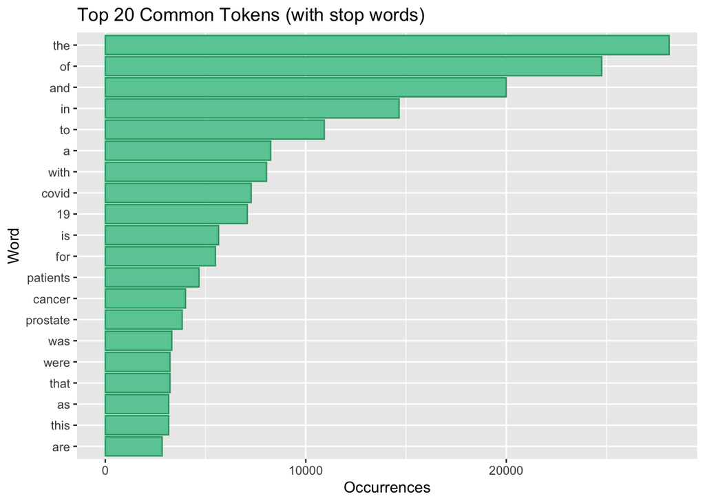

```r
# Read in data from provided repository
gitData <- read.csv("pubmed.csv")

# With stop words
gitData %>%
  unnest_tokens(output = word, input = abstract) %>%
  count(word, sort = TRUE) %>%
  top_n(20) %>%
  ggplot(aes(x = n, y = fct_reorder(word,n))) +
  geom_col(color = "#1FA971", fill = "#6ACBA4") +
  labs(x = "Occurrences", y = "Word", title = "Top 20 Common Tokens (with stop words)")
```

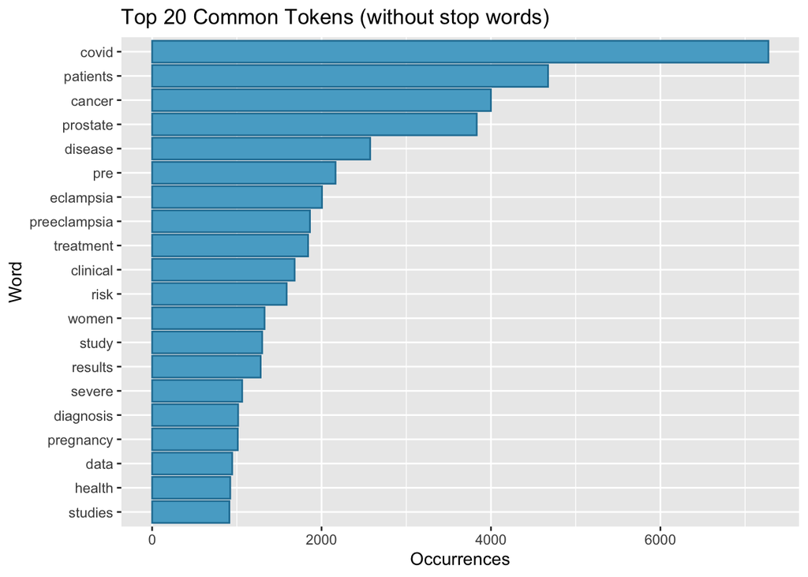

```r
# Without stop words
gitData %>%
  unnest_tokens(output = word, input = abstract) %>%
  count(word, sort = TRUE) %>%
  anti_join(stop_words, by = "word") %>%
  filter(!grepl(pattern = "^[0-9]+$", x = word)) %>%
  top_n(20) %>%
  ggplot(aes(x = n, y = fct_reorder(word,n))) +
  geom_col(color = "#247EA2", fill = "#57ABCD") +
  labs(x = "Occurrences", y = "Word", title = "Top 20 Common Tokens (without stop words)")
```

```r
gitData %>%
  unnest_tokens(output = word, input = abstract) %>%
  anti_join(stop_words, by = "word") %>%
  group_by(term) %>%
  count(word, sort = TRUE) %>%
  top_n(5) %>%
  knitr::kable(caption = "Top 5 Common Tokens for Each Term")
```

[output not shown]

When tokenizing the abstracts without removing stopwords, it is clear that stop words like “the” and “of” are most abundant. The first noticeable words that are not stop words are “covid” and “19,” which would be expected given the context of the dataset. Upon removing stop words, it is evident that the list of top 20 counted words changes and is more suited to give us better details about the dataset. After removing stop words, the top 5 common tokens were “covid,” “patients,” “cancer,” “prostate,” and “disease.”

By search term, the top 5 words are:

- “covid” - covid (7275), 19 (7035), patients (2293), disease (943), pandemic (800)
- “prostate cancer” - cancer (3840), prostate (3832), patients (934), treatment (926), disease (652)
- “preeclampsia” - pre (2038), eclampsia (2005), preeclampsia (1863), women (1196), pregnancy (969)
- “cystic fibrosis” - fibrosis (867), cystic (862), cf (625), patients (586), disease (400)
- “meningitis” - patients (446), meningitis (429), meningeal (219), csf (206), clinical (187)

Then, abstracts were tokenized into bigrams, and stop words were removed to avoid bigrams containining them too. A visual containing columns for each of the ten most common bigrams was created.

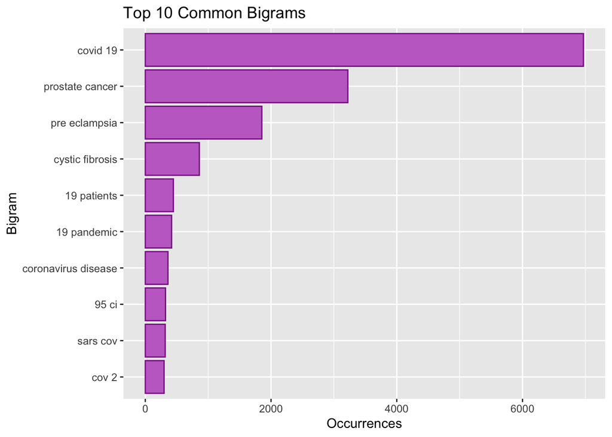

```r
gitData %>%
  unnest_ngrams(output = bigram, input = abstract, n = 2) %>%
  separate(bigram, c("word1", "word2"), sep = " ") %>%
  filter(!word1 %in% stop_words$word) %>%
  filter(!word2 %in% stop_words$word) %>%
  unite(bigram, word1, word2, sep = " ") %>%
  count(bigram, sort = TRUE) %>%
  top_n(10) %>%
  ggplot(aes(x = n, y = fct_reorder(bigram,n))) +
  geom_col(color = "#8A2893", fill = "#C470CB") +
  labs(x = "Occurrences", y = "Bigram", title = "Top 10 Common Bigrams")
```

Lastly, for each word-search term combination, TF-IDF values were calculated.

```r
#
gitData %>%
  unnest_tokens(output = word, input = abstract) %>%
  count(word, term) %>%
  bind_tf_idf(word, term, n) %>%
  arrange(desc(tf_idf)) %>%
  group_by(term) %>%
  top_n(5,tf_idf) %>%
  arrange(desc(term)) %>%
  knitr::kable(caption = "Top 5 Words for Each Search Term by TF-IDF Values, sorted by Term")
```

[output not shown]

- “prostate cancer” - androgen, psa, prostatectomy, castration
- “preeclampsia” - maternal, gestational
- “meningitis” - pachymeningitis, meninges
- “cystic fibrosis” - cftr, sweat
- “covid” - sars, coronavirus, cov